# Inventory Case Study

Maxim Ogarenko

11 декабря 2018 г

## Анализ запасов оптовой компании

Вы - финансист семейного офиса известного российского предпринимателя. Вам поручили провести финансовый анализ торговой компании, которую Ваш работодатель ракссматривает для покупки.

На данном этапе необходимо провести экспресс анализ качества запасов компании по состоянию на апрель 2018 г. В Вашем распоряжении выгрузка из 1С с:

1. продаж в натуральном и стоимостном выражении, по СКЮ, с июля по декабрь 2017 г., и с января по апрель 2018 г.
2. запасов в штуках на конец месяца за те же периоды
3. себестоимости в руб. каждого СКЮ

# Чтение всех файлов

```r
sales_units17 <- read.csv("sales_units2017.csv", header = TRUE, sep = ";")
sales_units18 <- read.csv("sales_units2018.csv", header = TRUE, sep = ";")
cogs <- read.csv("cog_per_unit.csv", header = TRUE, sep = ";", dec = ",")
stock17 <- read.csv("stock_units2017.csv", header = TRUE, sep = ";")
stock18 <- read.csv("stock_units2018.csv", header = TRUE, sep = ";")
```

Посмотрев на исходные данные, мы видим, что номенклатура товаров в разных файлах не полностью совпадает. При этом мы уверены в том, что учётная система анализируемой компании обеспечивала единство названий во всех типах отчетов.

# Формирование единого списка товаров

Извлечём векторы с названиями товара из всех таблиц, объединим в один, после чего оставим только уникальные значения.

```r
skus <- c(as.character(sales_units17[, 1]),
         as.character(sales_units18[, 1]),
         as.character(stock17[, 1]),
         as.character(stock18[, 1]),
         as.character(cogs$SKU))
skus <- data.frame(unique(skus))
```

# Правка заголовков таблиц

Нам потребуется объединять эти таблицы. Для этого нам необходимо обеспечить одинаковое название столбца с наименованиями во всех таблицах.

```r
colnames(skus) <- "SKU"
names(stock17)[1] <- "SKU"
names(stock18)[1] <- "SKU"
names(sales_units17)[1] <- "SKU"
names(sales_units18)[1] <- "SKU"
```

# Формирование объединённой таблицы с запасами

Объединим список уникальных названий, запасы 2017 и 2018 г.г. Перепишем NA как 0.

```r
stock <- merge(skus, stock17, all = TRUE, by = "SKU")
stock <- merge(stock, all = TRUE, stock18)
stock[is.na(stock)] <- 0
```

# Формирование объединённой таблицы со среднедневными продажами в шт.

Мы будем использовать тот же перечень номенклатуры для таблицы с продажами.

```r
sales <- merge(skus, sales_units17, all = TRUE, by = "SKU")
sales <- merge(sales, sales_units18, all = TRUE, by = "SKU")
sales[, -1][sales[, -1] < 0] <- 0
sales[is.na(sales)] <- 0
daily_sales <- sales[, -1] / 30
```

# Формирование таблицы с себестоимостью

“Подтянем” себестоимости каждого СКЮ в тот же перечень номенклатуры.

```r
cogs <- merge(skus, cogs, all = TRUE, by = "SKU")
cogs[is.na(cogs)] <- 0
```

# Расчёт сроков оборачиваемости

Рассчитаем сроки оборачиваемости каждого СКЮ в каждом месяце как запасы на конец месяца / среднедневные продажи. Деление на нулевые продажи месяца даёт бесконечность - обратим значения Inf в 0.

Таблицы с запасами и продажами имеют одинаковую номенклатуру, что позволяет производить деление датафрейма на датафрейм.

```r
inv_days <- as.matrix(stock[, -1] / daily_sales)
inv_days[!is.finite(inv_days)] <- 0
inv_days <- data.frame(skus, inv_days)
```

# Формирование таблицы с запасами в руб.

Умножим запасы на себестоимость штуки, суммируем месячные итоги.

```r
inventory <- as.matrix(stock[, -1] * cogs$COG)
inventory <- data.frame(skus, inventory)
inventory_totals <- unname(round(colSums(inventory[, -1])/10^6, 1))
```

# Расчёт дефицитов

Сформируем таблицу с дефицитом в днях продаж. Умножим эту таблицу на среднедневные продажи, получив дефициты в штуках. Умножим натуральные дефициты на себестоимость, суммируем итоги.

```r
deficit_days <- 90
deficit <- deficit_days - inv_days[, -1]
deficit[deficit < 0] <- 0
deficit <- deficit * daily_sales * cogs$COG
deficit <- data.frame(skus, deficit)
deficit_totals <- unname(round(colSums(deficit[, -1])/10^6, 1))
```

# Расчёт излишков

Аналогично.

```r
overstock_days <- 150
overstock <- inv_days[, -1] - overstock_days
overstock[overstock < 0] <- 0
overstock <- overstock * daily_sales * cogs$COG
overstock <- data.frame(skus, overstock)
overstock_totals <- unname(round(colSums(overstock[, -1])/10^6, 1))
```

# Итоговый отчёт

```r
report <- data.frame(colnames(stock)[2:11],
                     inventory_totals,
                     deficit_totals,
                     overstock_totals)
colnames(report) <- c("Month", "Inventory", "Deficit", "Overstock")
{print("Inventory, Deficits and Overstocks, in mln Rub")
report}
```

```
## [1] "Inventory, Deficits and Overstocks, in mln Rub"
```

```
##     Month Inventory Deficit Overstock
## 1  июл.17      45.6    23.3      11.6
## 2  авг.17      54.9    25.3      14.7
## 3  сен.17      59.9    20.4      15.0
## 4  окт.17      51.3    24.2      12.3
## 5  ноя.17      68.5    39.2      13.1
## 6  дек.17      70.0    89.2      13.5
## 7  янв.18      73.9    10.8      31.4
## 8  фев.18      76.6     8.8      31.7
## 9  мар.18      74.2    22.6      28.3
## 10 апр.18      65.9    19.8      19.3
```

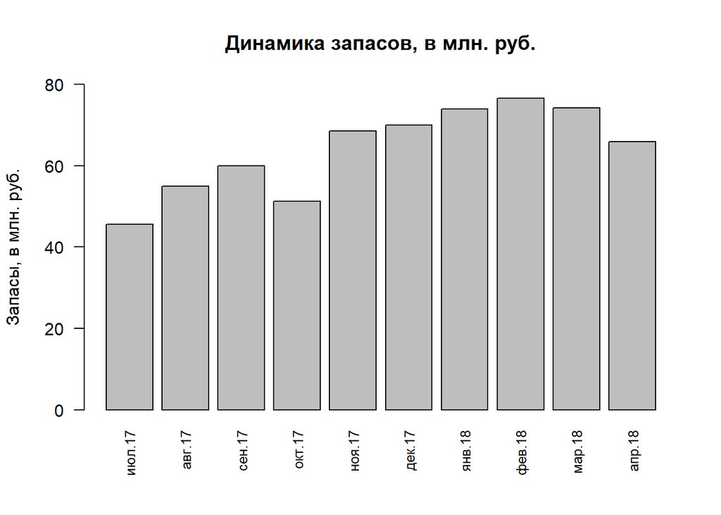

```r
barplot(height = inventory_totals,
        names.arg = report$Month,
        ylim = c(0, 80),
        ylab = "Запасы, в млн. руб.",
        cex.names = 0.8,
        las = 2,
        main = "Динамика запасов, в млн. руб.")
```

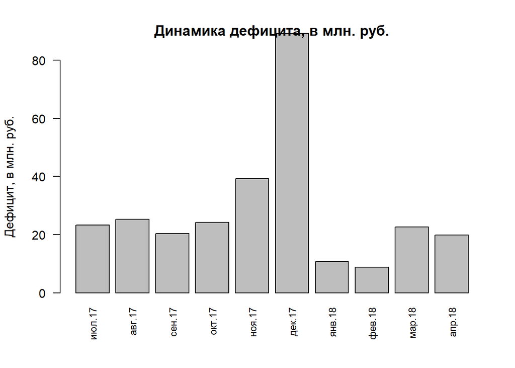

```r
barplot(height = deficit_totals,
        names.arg = report$Month,
        ylim = c(0, 80),
        ylab = "Дефицит, в млн. руб.",
        cex.names = 0.8,
        las = 2,
        main = "Динамика дефицита, в млн. руб.")
```

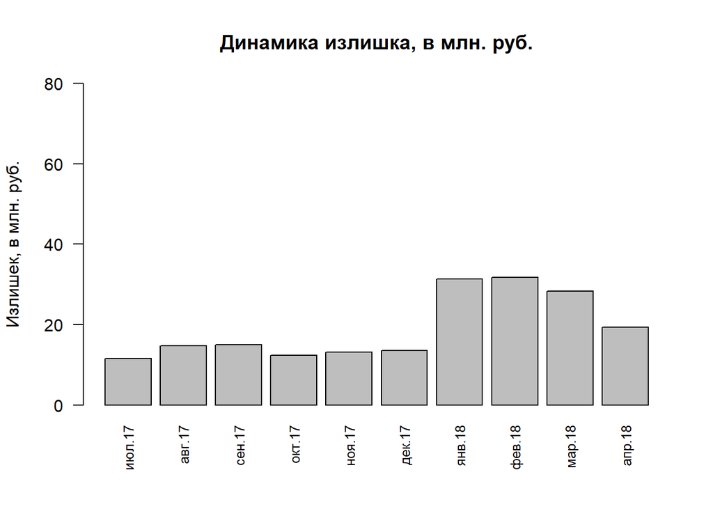

```r
barplot(height = overstock_totals,
        names.arg = report$Month,
        ylim = c(0, 80),
        ylab = "Излишек, в млн. руб.",
        cex.names = 0.8,
        las = 2,
        main = "Динамика излишка, в млн. руб.")
```